# Assignment 9: RU23 Full Deployment Data Visualization

#### Now that 23 is in, let's look at the data from the glider, using what code we know and adding a few more features

```python
# Our usual imports
import xarray as xr
import pandas as pd
import matplotlib.pyplot as plt
import cool_maps.plot as cplt
import cartopy.crs as ccrs
import cmocean.cm as cmo
```

```python
# Load in the URL for the Real-Time Science data from tabledap http://slocum-data.marine.rutgers.edu/erddap/tabledap/ru23-20231019T1528-profile-sci-rt.html
url  = 'https://slocum-data.marine.rutgers.edu/erddap/tabledap/ru23-20241022T1512-profile-sci-rt.csv?time%2Clatitude%2Clongitude%2Cdepth%2Cbeta_470nm%2Cbeta_532nm%2Cbeta_660nm%2Ccdom%2Cchlorophyll_a%2Cdensity%2Csalinity%2Ctemperature'
ru23_rt = pd.read_csv(url, sep=',', skiprows=range(1, 2), parse_dates=['time'])
ru23_rt
```

|  | time | latitude | longitude | depth | beta_470nm | beta_532nm | beta_660nm | cdom | chlorophyll_a | density | salinity | temperature |
| --- | --- | --- | --- | --- | --- | --- | --- | --- | --- | --- | --- | --- |
| 0 | 2024-10-22 15:47:07+00:00 | 39.437300 | -74.208252 | 3.771048 | 0.001753 | 0.001986 | 0.001236 | 0.3748 | 0.3936 | 1022.76935 | 31.514950 | 17.4042 |
| 1 | 2024-10-22 15:47:11+00:00 | 39.437292 | -74.208243 | 4.396242 | 0.001700 | 0.001996 | 0.001232 | 1.1244 | 0.5781 | 1022.78020 | 31.520287 | 17.3873 |
| 2 | 2024-10-22 15:47:12+00:00 | 39.437291 | -74.208242 | NaN | NaN | NaN | NaN | NaN | NaN | NaN | NaN | NaN |
| 3 | 2024-10-22 15:47:15+00:00 | 39.437284 | -74.208235 | 5.051204 | 0.001718 | 0.002149 | 0.001218 | 1.3118 | 0.9348 | 1022.78790 | 31.523035 | 17.3758 |
| 4 | 2024-10-22 15:47:20+00:00 | 39.437276 | -74.208226 | 5.735935 | 0.001753 | 0.002053 | 0.001196 | 0.0937 | 0.7995 | 1022.79500 | 31.527576 | 17.3736 |
| ... | ... | ... | ... | ... | ... | ... | ... | ... | ... | ... | ... | ... |
| 80748 | 2024-11-04 12:53:48+00:00 | 39.413173 | -74.150608 | 5.507704 | NaN | NaN | NaN | NaN | NaN | 1023.25490 | 31.910238 | 16.6516 |
| 80749 | 2024-11-04 12:53:56+00:00 | 39.413169 | -74.150619 | 4.495488 | NaN | NaN | NaN | NaN | NaN | 1023.25120 | 31.910471 | 16.6485 |
| 80750 | 2024-11-04 12:54:04+00:00 | 39.413165 | -74.150630 | 3.423725 | NaN | NaN | NaN | NaN | NaN | 1023.24396 | 31.908585 | 16.6531 |
| 80751 | 2024-11-04 12:54:05+00:00 | 39.413165 | -74.150630 | NaN | NaN | NaN | NaN | NaN | NaN | NaN | NaN | NaN |
| 80752 | 2024-11-04 12:54:12+00:00 | 39.413161 | -74.150640 | 2.768756 | NaN | NaN | NaN | NaN | NaN | 1023.24304 | 31.910133 | 16.6496 |

80753 rows × 12 columns

```python
# Look at just our data columns that we can work with
ru23_rt.keys()
```

```
Index(['time', 'latitude', 'longitude', 'depth', 'beta_470nm', 'beta_532nm',
       'beta_660nm', 'cdom', 'chlorophyll_a', 'density', 'salinity',
       'temperature'],
      dtype='object')
```

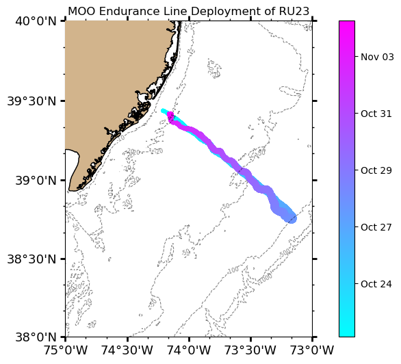

```python
# Now we can plot our data on top of a nice map from Mike Smith's cool_maps
extent     = [-75, -73, 38, 40]
markersize = 5;

fig,axs  = cplt.create(extent, proj=ccrs.Mercator(), bathymetry=True, isobaths=(-1000, -500, -100, -50, -20, -10), figsize=(10,6), oceancolor='w')
ax_posi = plt.scatter(ru23_rt['longitude'],ru23_rt['latitude'],ru23_rt['depth'],c=ru23_rt['time'], marker="o", edgecolors='none',cmap='cool', transform=ccrs.PlateCarree())

#Add in a title
plt.title('MOO Endurance Line Deployment of RU23');

# Date colorbar code taken from: https://stackoverflow.com/questions/51160705/plot-time-series-with-colorbar-in-pandas-matplotlib
# Define your mappable for colorbar creation
sm = plt.cm.ScalarMappable(cmap='cool',
                           norm=plt.Normalize(vmin=ru23_rt['time'].min().value,
                                              vmax=ru23_rt['time'].max().value));
sm._A = [];
# Add your colorbar
cbar = plt.colorbar(sm,  ax = axs);
# Change the numeric ticks into ones that match. Time format options detailed here: https://docs.python.org/3/library/datetime.html#strftime-and-strptime-behavior
cbar.ax.set_yticklabels(pd.to_datetime(cbar.get_ticks()).strftime(date_format='%b %d'));
```

#### We're plotting in 3 dimensions (longitude, latitude, and depth) but we only see a 2D plot? Can't we just leave out depth?

### Of course we *could*, but do we want to?

#### What if instead we visualize our data using all three of the dimensions plotted?

#### Let's take that same block of code from above, and rework it a bit...

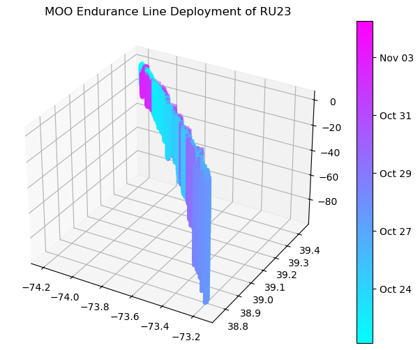

```python
fig = plt.figure(figsize=(10, 6))
axs  = fig.add_subplot(projection='3d')

# Converts the time into a usable color range for 3D plotting
ru23_rt['date'] = pd.to_numeric(pd.to_datetime(ru23_rt['time']))

axs.scatter(ru23_rt['longitude'],ru23_rt['latitude'],-ru23_rt['depth'],c=ru23_rt['date'], marker="o", edgecolors='none',cmap='cool')

#Add in a title
plt.title('MOO Endurance Line Deployment of RU23');

# Date colorbar code taken from: https://stackoverflow.com/questions/51160705/plot-time-series-with-colorbar-in-pandas-matplotlib
# Define your mappable for colorbar creation
sm = plt.cm.ScalarMappable(cmap='cool',
                           norm=plt.Normalize(vmin=ru23_rt['time'].min().value,
                                              vmax=ru23_rt['time'].max().value));
sm._A = [];
# Add your colorbar
cbar = plt.colorbar(sm,  ax = axs);
# Change the numeric ticks into ones that match. Time format options detailed here: https://docs.python.org/3/library/datetime.html#strftime-and-strptime-behavior
cbar.ax.set_yticklabels(pd.to_datetime(cbar.get_ticks()).strftime(date_format='%b %d'));

axs.view_init(30, 300)
```

#### Now what if we wanted to look at some ocean conditions instead?

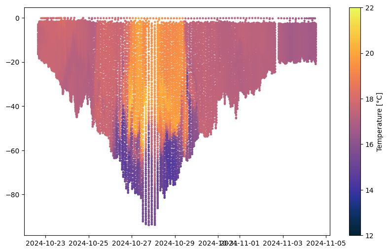

```python
# We can plot these in 2D
fig = plt.figure(figsize=(10,6))
plt.scatter(ru23_rt['time'],-ru23_rt['depth'],10,ru23_rt['temperature'],vmin=12, vmax=22, marker="o", edgecolors='none',cmap = cmo.thermal)
cb = plt.colorbar()
cb.set_label('Temperature [°C]')
```

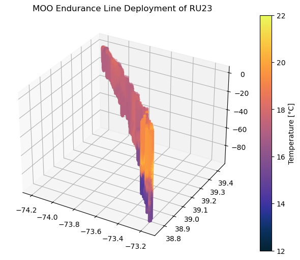

```python
# Or in 3D
fig = plt.figure(figsize=(10, 6))
ax = fig.add_subplot(projection='3d')

ru23_rt['date'] = pd.to_numeric(pd.to_datetime(ru23_rt['time']))

ax_temp = ax.scatter(ru23_rt['longitude'],ru23_rt['latitude'],-ru23_rt['depth'],c=ru23_rt['temperature'],vmin=12, vmax=22, marker="o", edgecolors='none',cmap=cmo.thermal)

#Add in a title
plt.title('MOO Endurance Line Deployment of RU23');

# Add your colorbar
cb = plt.colorbar(ax_temp)
cb.set_label('Temperature [°C]')

ax.view_init(30, 300)
```

# Assignment: Can you create some 2D or 3D plots of the glider's full deployment (delayed dataset, ru23_de)?

```python
# Load in the URL for the Delayed Science data from tabledap http://slocum-data.marine.rutgers.edu/erddap/tabledap/ru23-20231019T1528-profile-sci-delayed.html
url  = 'https://slocum-data.marine.rutgers.edu/erddap/tabledap/ru23-20241022T1512-profile-sci-delayed.csv?time%2Clatitude%2Clongitude%2Cdepth%2Cbeta_470nm%2Cbeta_532nm%2Cbeta_660nm%2Ccdom%2Cchlorophyll_a%2Cdensity%2Csalinity%2Ctemperature'
ru23_de = pd.read_csv(url, sep=',', skiprows=range(1, 2), parse_dates=['time'])
ru23_de
```

|  | time | latitude | longitude | depth | beta_470nm | beta_532nm | beta_660nm | cdom | chlorophyll_a | density | salinity | temperature |
| --- | --- | --- | --- | --- | --- | --- | --- | --- | --- | --- | --- | --- |
| 0 | 2024-10-22 15:35:36+00:00 | 39.438168 | -74.208060 | 0.049620 | 0.000193 | 0.000191 | 0.000142 | 0.3748 | 0.3813 | 997.54990 | 0.140331 | 23.4130 |
| 1 | 2024-10-22 15:35:40+00:00 | 39.438168 | -74.208060 | NaN | NaN | NaN | NaN | NaN | NaN | NaN | NaN | NaN |
| 2 | 2024-10-22 15:35:40+00:00 | 39.438168 | -74.208060 | 0.049620 | 0.000193 | 0.000191 | 0.000142 | 0.3748 | 0.3813 | 997.54990 | 0.140331 | 23.4130 |
| 3 | 2024-10-22 15:36:35+00:00 | 39.438168 | -74.208060 | NaN | NaN | NaN | NaN | NaN | NaN | NaN | NaN | NaN |
| 4 | 2024-10-22 15:36:51+00:00 | 39.438125 | -74.208112 | NaN | NaN | NaN | NaN | NaN | NaN | NaN | NaN | NaN |
| ... | ... | ... | ... | ... | ... | ... | ... | ... | ... | ... | ... | ... |
| 937412 | 2024-11-04 14:46:06+00:00 | 39.415074 | -74.147831 | 0.178631 | NaN | NaN | NaN | NaN | NaN | 1023.22850 | 31.910170 | 16.6625 |
| 937413 | 2024-11-04 14:46:07+00:00 | 39.415075 | -74.147829 | NaN | NaN | NaN | NaN | NaN | NaN | NaN | NaN | NaN |
| 937414 | 2024-11-04 14:46:08+00:00 | 39.415077 | -74.147825 | 0.248098 | NaN | NaN | NaN | NaN | NaN | 1023.23140 | 31.912520 | 16.6593 |
| 937415 | 2024-11-04 14:46:10+00:00 | 39.415079 | -74.147819 | 0.218326 | NaN | NaN | NaN | NaN | NaN | 1023.22906 | 31.909775 | 16.6596 |
| 937416 | 2024-11-04 14:46:11+00:00 | 39.415080 | -74.147816 | 0.168707 | NaN | NaN | NaN | NaN | NaN | 1023.23070 | 31.911640 | 16.6575 |

937417 rows × 12 columns

### #1. A figure with 4-subplots of 2D (time, depth) plots showing temperature, salinity, density, and chlorophyll

```python
print(ru23_de["temperature"].min())
print(ru23_de["temperature"].max())

print(ru23_de["salinity"].min())
print(ru23_de["salinity"].max())

print(ru23_de["density"].min())
print(ru23_de["density"].max())

print(ru23_de["chlorophyll_a"].min())
print(ru23_de["chlorophyll_a"].max())
```

```
14.3973
23.413
0.14033085
35.892803
997.5499
1026.7665
-0.3444
5.166
```

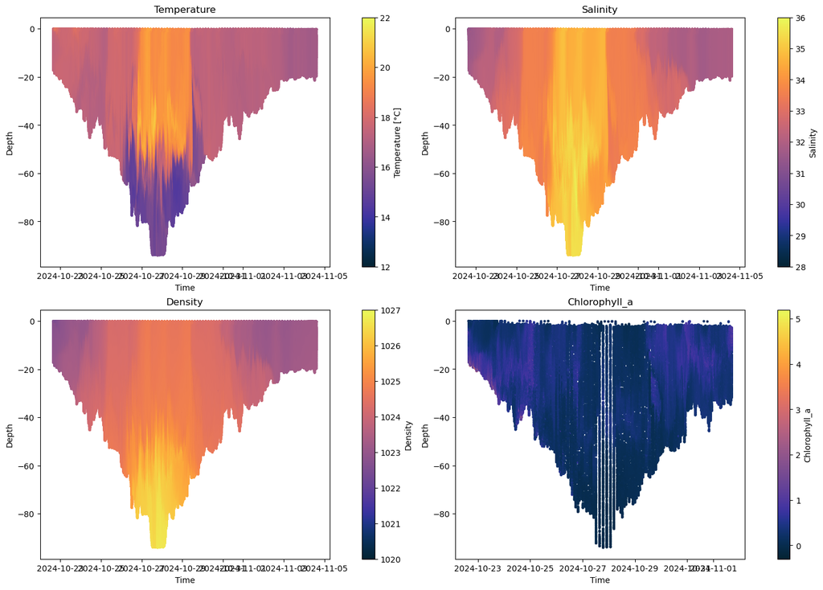

```python
fig, axs = plt.subplots(2, 2, figsize=(14, 10), constrained_layout=True)

# Temperature
sc1 = axs[0, 0].scatter(ru23_de['time'], -ru23_de['depth'],10, c=ru23_de['temperature'], cmap=cmo.thermal, vmin=12, vmax=22,edgecolors='none')
cb1 = fig.colorbar(sc1, ax=axs[0, 0])
cb1.set_label('Temperature [°C]')
axs[0, 0].set_title('Temperature')
axs[0, 0].set_xlabel('Time')
axs[0, 0].set_ylabel('Depth')

# Salinity
sc2 = axs[0, 1].scatter(ru23_de['time'],-ru23_de['depth'],10, c=ru23_de['salinity'],cmap=cmo.thermal,vmin=28, vmax=36,edgecolors='none')
cb2 = fig.colorbar(sc2, ax=axs[0, 1])
cb2.set_label('Salinity')
axs[0, 1].set_title('Salinity')
axs[0, 1].set_xlabel('Time')
axs[0, 1].set_ylabel('Depth')

# Density
sc3 = axs[1, 0].scatter(ru23_de['time'],-ru23_de['depth'],10, c=ru23_de['density'],cmap=cmo.thermal,vmin=1020, vmax=1027,edgecolors='none')
cb3 = fig.colorbar(sc3, ax=axs[1, 0])
cb3.set_label('Density')
axs[1, 0].set_title('Density')
axs[1, 0].set_xlabel('Time')
axs[1, 0].set_ylabel('Depth')

# Chlorophyll_a
sc4 = axs[1, 1].scatter(ru23_de['time'],-ru23_de['depth'],10, c=ru23_de['chlorophyll_a'], cmap=cmo.thermal,vmin=-0.3, vmax=5.2, edgecolors='none')
cb4 = fig.colorbar(sc4, ax=axs[1, 1])
cb4.set_label('Chlorophyll_a')
axs[1, 1].set_title('Chlorophyll_a')
axs[1, 1].set_xlabel('Time')
axs[1, 1].set_ylabel('Depth')

plt.show()
```

### #2. A figure with 4-subplots of daily mean time series plots showing temperature, salinity, density, and chlorophyll

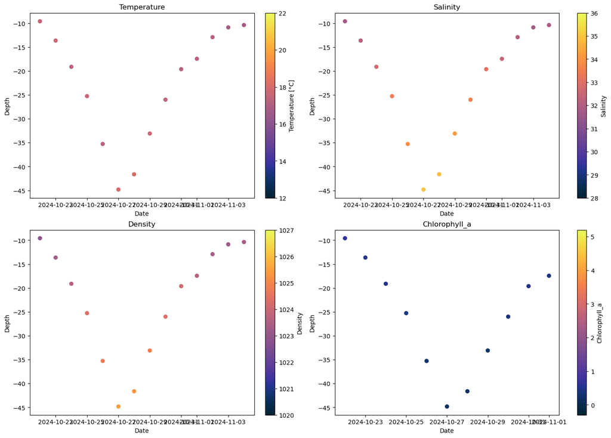

```python
ru23_de['time'] = pd.to_datetime(ru23_de['time'])

# Create a 'date' column for grouping
ru23_de['date'] = ru23_de['time'].dt.date

# Calculate daily mean for each parameter
daily_means = ru23_de.groupby('date').mean().reset_index()

fig, axs = plt.subplots(2, 2, figsize=(14, 10), constrained_layout=True)

# Temperature
sc1 = axs[0, 0].scatter(daily_means['date'], -daily_means['depth'], s=50, c=daily_means['temperature'],cmap=cmo.thermal, vmin=12, vmax=22, edgecolors='none')
cb1 = fig.colorbar(sc1, ax=axs[0, 0])
cb1.set_label('Temperature [°C]')
axs[0, 0].set_title('Temperature')
axs[0, 0].set_xlabel('Date')
axs[0, 0].set_ylabel('Depth')

# Salinity
sc2 = axs[0, 1].scatter(daily_means['date'], -daily_means['depth'], s=50, c=daily_means['salinity'], cmap=cmo.thermal, vmin=28, vmax=36, edgecolors='none')
cb2 = fig.colorbar(sc2, ax=axs[0, 1])
cb2.set_label('Salinity')
axs[0, 1].set_title('Salinity')
axs[0, 1].set_xlabel('Date')
axs[0, 1].set_ylabel('Depth')

# Density
sc3 = axs[1, 0].scatter(daily_means['date'], -daily_means['depth'], s=50, c=daily_means['density'],cmap=cmo.thermal, vmin=1020, vmax=1027, edgecolors='none')
cb3 = fig.colorbar(sc3, ax=axs[1, 0])
cb3.set_label('Density')
axs[1, 0].set_title('Density')
axs[1, 0].set_xlabel('Date')
axs[1, 0].set_ylabel('Depth')

# Chlorophyll_a
sc4 = axs[1, 1].scatter(daily_means['date'], -daily_means['depth'], s=50, c=daily_means['chlorophyll_a'],cmap=cmo.thermal, vmin=-0.3, vmax=5.2, edgecolors='none')
cb4 = fig.colorbar(sc4, ax=axs[1, 1])
cb4.set_label('Chlorophyll_a')
axs[1, 1].set_title('Chlorophyll_a')
axs[1, 1].set_xlabel('Date')
axs[1, 1].set_ylabel('Depth')

plt.show()
```

### #3. A figure with 4-subplots of 3D (longitude, latitude, depth) plots showing temperature, salinity, density, and chlorophyll

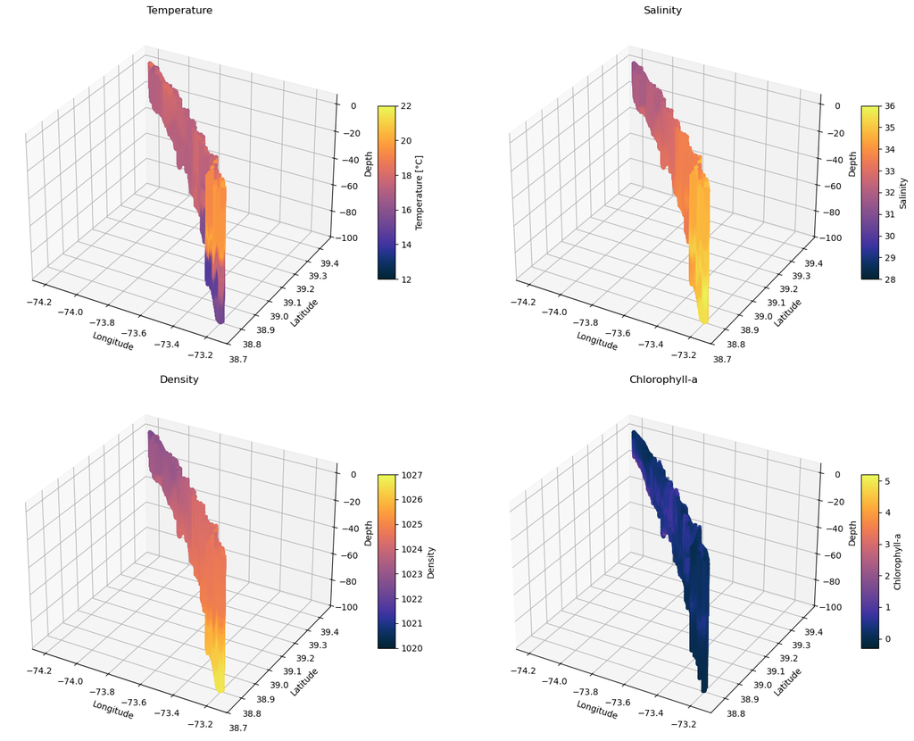

```python
fig = plt.figure(figsize=(16, 12))

# Plot for Temperature
ax1 = fig.add_subplot(2, 2, 1, projection='3d')
ax_temp = ax1.scatter(ru23_de['longitude'], ru23_de['latitude'], -ru23_de['depth'], c=ru23_de['temperature'],vmin=12, vmax=22, marker="o", edgecolors='none', cmap=cmo.thermal)
ax1.set_title('Temperature')
ax1.set_xlabel('Longitude')
ax1.set_ylabel('Latitude')
ax1.set_zlabel('Depth')
cb1 = fig.colorbar(ax_temp, ax=ax1, shrink=0.5, aspect=10)
cb1.set_label('Temperature [°C]')
ax1.view_init(30, 300)

# Plot for Salinity
ax2 = fig.add_subplot(2, 2, 2, projection='3d')
ax_salinity = ax2.scatter(ru23_de['longitude'], ru23_de['latitude'], -ru23_de['depth'], c=ru23_de['salinity'],vmin=28, vmax=36, marker="o", edgecolors='none', cmap=cmo.thermal)
ax2.set_title('Salinity')
ax2.set_xlabel('Longitude')
ax2.set_ylabel('Latitude')
ax2.set_zlabel('Depth')
cb2 = fig.colorbar(ax_salinity, ax=ax2, shrink=0.5, aspect=10)
cb2.set_label('Salinity')
ax2.view_init(30, 300)

# Plot for Density
ax3 = fig.add_subplot(2, 2, 3, projection='3d')
ax_density = ax3.scatter(ru23_de['longitude'], ru23_de['latitude'], -ru23_de['depth'], c=ru23_de['density'],vmin=1020, vmax=1027, marker="o", edgecolors='none', cmap=cmo.thermal)
ax3.set_title('Density')
ax3.set_xlabel('Longitude')
ax3.set_ylabel('Latitude')
ax3.set_zlabel('Depth')
cb3 = fig.colorbar(ax_density, ax=ax3, shrink=0.5, aspect=10)
cb3.set_label('Density')
ax3.view_init(30, 300)

# Plot for Chlorophyll-a
ax4 = fig.add_subplot(2, 2, 4, projection='3d')
ax_CHL = ax4.scatter(ru23_de['longitude'], ru23_de['latitude'], -ru23_de['depth'], c=ru23_de['chlorophyll_a'], vmin=-0.3, vmax=5.2, marker="o", edgecolors='none', cmap=cmo.thermal)
ax4.set_title('Chlorophyll-a')
ax4.set_xlabel('Longitude')
ax4.set_ylabel('Latitude')
ax4.set_zlabel('Depth')
cb4 = fig.colorbar(ax_CHL, ax=ax4, shrink=0.5, aspect=10)
cb4.set_label('Chlorophyll-a')
ax4.view_init(30, 300)

plt.tight_layout()
plt.show()
```

### #4. TS diagrams colored by time, one for the real-time and one for the delayed

```python
import numpy as np
import gsw
import matplotlib.dates as mdates
ru23_rt['date'] = pd.to_numeric(pd.to_datetime(ru23_rt['time']))
ru23_de['date'] = pd.to_numeric(pd.to_datetime(ru23_de['time']))
```

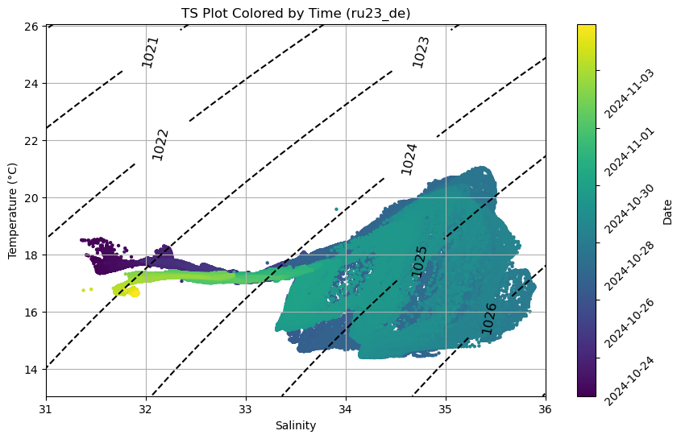

```python
salt = ru23_de['salinity']
temp = ru23_de['temperature']
time = pd.to_datetime(ru23_de['time'])  # Ensure time is datetime

time_numeric = mdates.date2num(time)  # Convert datetime to matplotlib date format
density_levels = np.arange(np.floor(dens.min()), np.ceil(dens.max()) + 1, 1)
# Calculate boundaries
smin = salt.min() - (0.01 * salt.min())
smax = salt.max() + (0.01 * salt.max())
tmin = temp.min() - (0.1 * temp.max())
tmax = temp.max() + (0.1 * temp.max())

# Calculate how many grid cells we need in the x and y dimensions
xdim = round((smax - smin) / 0.1 + 1, 0)
ydim = round((tmax - tmin) + 1, 0)

# Create an empty grid of zeros
dens = np.zeros((int(ydim), int(xdim)))

# Create temperature and salinity vectors of appropriate dimensions
ti = np.linspace(1, int(ydim) - 1, int(ydim)) + tmin
si = np.linspace(1, int(xdim) - 1, int(xdim)) * 0.1 + smin

# Loop to fill in the grid with densities
for j in range(0, int(ydim)):
    for i in range(0, int(xdim)):
        dens[j, i] = gsw.rho(si[i], ti[j], 0)  # Absolute salinity and conservative temperature

#xlim
x_min = 31
x_max = 36

# Plot
fig1 = plt.figure(figsize=(10, 6))
ax1 = fig1.add_subplot(111)

# Density contours
CS = plt.contour(si, ti, dens, levels=density_levels, linestyles='dashed', colors='k')
plt.clabel(CS, fontsize=12, inline=1, fmt='%1.0f')  # Label every contour

# Scatter with time
sc = ax1.scatter(salt, temp, c=time_numeric, cmap='viridis', s=10, edgecolor='none')

# Add color bar for time
cbar = plt.colorbar(sc)
cbar.set_label('Date')
cbar.ax.yaxis.set_major_formatter(mdates.DateFormatter('%Y-%m-%d'))  # Format color bar as dates
plt.setp(cbar.ax.yaxis.get_majorticklabels(), rotation=45)


# Axis labels and plot title
ax1.set_xlabel('Salinity')
ax1.set_ylabel('Temperature (°C)')
ax1.set_title('TS Plot Colored by Time (ru23_de)')
ax1.set_xlim(x_min, x_max)
plt.grid(True)
plt.show()
```

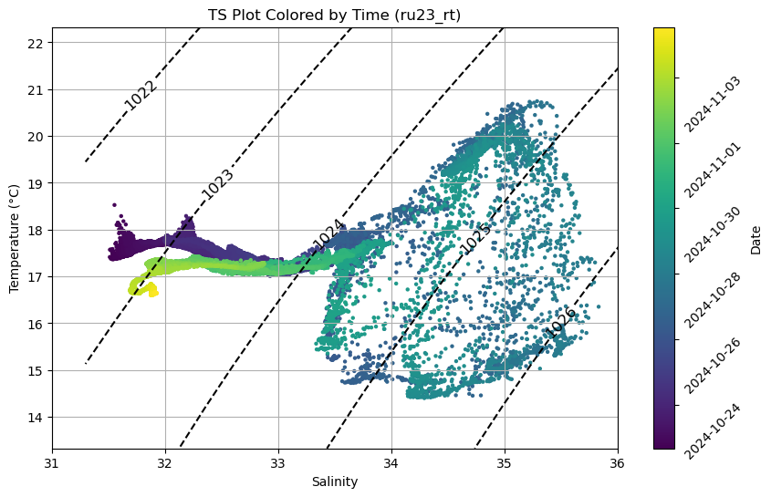

```python
# Extract variables from ru23_rt
salt = ru23_rt['salinity']
temp = ru23_rt['temperature']
time = pd.to_datetime(ru23_rt['time'])  # Ensure time is in datetime format

# Convert time to numeric for plotting
time_numeric = mdates.date2num(time)  # Convert datetime to matplotlib date format

# Calculate density levels for contour lines
density_levels = np.arange(np.floor(dens.min()), np.ceil(dens.max()) + 1, 1)

# Calculate boundaries
smin = salt.min() - (0.01 * salt.min())
smax = salt.max() + (0.01 * salt.max())
tmin = temp.min() - (0.1 * temp.max())
tmax = temp.max() + (0.1 * temp.max())

# Calculate how many grid cells we need in the x and y dimensions
xdim = round((smax - smin) / 0.1 + 1, 0)
ydim = round((tmax - tmin) + 1, 0)

# Create an empty grid of zeros
dens = np.zeros((int(ydim), int(xdim)))

# Create temperature and salinity vectors of appropriate dimensions
ti = np.linspace(1, int(ydim) - 1, int(ydim)) + tmin
si = np.linspace(1, int(xdim) - 1, int(xdim)) * 0.1 + smin

# Loop to fill in the grid with densities
for j in range(0, int(ydim)):
    for i in range(0, int(xdim)):
        dens[j, i] = gsw.rho(si[i], ti[j], 0)  # Absolute salinity and conservative temperature

# Define x-axis limits
x_min = 31
x_max = 36

# Plot
fig1 = plt.figure(figsize=(10, 6))
ax1 = fig1.add_subplot(111)

# Density contours
CS = plt.contour(si, ti, dens, levels=density_levels, linestyles='dashed', colors='k')
plt.clabel(CS, fontsize=12, inline=1, fmt='%1.0f')  # Label every contour

# Scatter with time
sc = ax1.scatter(salt, temp, c=time_numeric, cmap='viridis', s=10, edgecolor='none')

# Add color bar for time
cbar = plt.colorbar(sc)
cbar.set_label('Date')
cbar.ax.yaxis.set_major_formatter(mdates.DateFormatter('%Y-%m-%d'))  # Format color bar as dates
plt.setp(cbar.ax.yaxis.get_majorticklabels(), rotation=45)

# Axis labels and plot title
ax1.set_xlabel('Salinity')
ax1.set_ylabel('Temperature (°C)')
ax1.set_title('TS Plot Colored by Time (ru23_rt)')
ax1.set_xlim(x_min, x_max)
plt.grid(True)
plt.show()
```

### #5. What differences do you note with the delayed dataset? Are there any advantages to using this dataset instead of the real-time? What disadvantages are there?

The real time hs less data in the center mass of the TS plot. Roughly the shape is the same between the two plots but delayed has much more data. Delayed has more processed and analyzed data which produces a sharper more defined image. Real time data is much faster and can be viewed before the delayed data has been sent off. Delayed is better for more detailed view of data while real time is better for speed.